# Task1

Загрузим наши данные:

```r
df <- read.table(file = 'study_fall2020_dataprog_creditcard.txt',
                sep = ';',
                header = TRUE)
head(df)
```

```
##   card reports      age income       share expenditure owner selfemp dependents
## 1  yes       0 37.66667 4.5200 0.033269910  124.983300   yes      no          3
## 2  yes       0 33.25000 2.4200 0.005216942    9.854167    no      no          3
## 3  yes       0 33.66667 4.5000 0.004155556   15.000000   yes      no          4
## 4  yes       0 30.50000 2.5400 0.065213780  137.869200    no      no          0
## 5  yes       0 32.16667 9.7867 0.067050590  546.503300   yes      no          2
## 6  yes       0 23.25000 2.5000 0.044438400   91.996670    no      no          0
##   months majorcards active
## 1     54          1     12
## 2     34          1     13
## 3     58          1      5
## 4     25          1      7
## 5     64          1      5
## 6     54          1      1
```

## Информация о dataset:

card: Factor. Was the application for a credit card accepted?

reports: Number of major derogatory reports.

age: Age in years plus twelfths of a year.

income: Yearly income (in USD 10,000).

share: Ratio of monthly credit card expenditure to yearly income.

expenditure: Average monthly credit card expenditure.

owner: Factor. Does the individual own their home?

selfemp: Factor. Is the individual self-employed?

dependents: Number of dependents.

months: Months living at current address.

majorcards: Number of major credit cards held.

active: Number of active credit accounts.

## Task:

1. Write a dataframe with the following properties:
- Let’s consider ‘today’ is 2000-01-01. Convert amount of months applicant living at his/her current address to days
- Add column with income per family member (not the number of dependents!) inPerFamMem in USD 10,000

```r
library(lubridate)
library(dplyr)
library(plyr)
now <- as.Date("2000-01-01")
df <- mutate(df, days = as.numeric( (now %m+% months(months)) - now),
             inPerFamMem = income/(dependents + 1))

head(df)
```

```
##   card reports      age income       share expenditure owner selfemp dependents
## 1  yes       0 37.66667 4.5200 0.033269910  124.983300   yes      no          3
## 2  yes       0 33.25000 2.4200 0.005216942    9.854167    no      no          3
## 3  yes       0 33.66667 4.5000 0.004155556   15.000000   yes      no          4
## 4  yes       0 30.50000 2.5400 0.065213780  137.869200    no      no          0
## 5  yes       0 32.16667 9.7867 0.067050590  546.503300   yes      no          2
## 6  yes       0 23.25000 2.5000 0.044438400   91.996670    no      no          0
##   months majorcards active days inPerFamMem
## 1     54          1     12 1643    1.130000
## 2     34          1     13 1035    0.605000
## 3     58          1      5 1766    0.900000
## 4     25          1      7  762    2.540000
## 5     64          1      5 1947    3.262233
## 6     54          1      1 1643    2.500000
```

- Define your own criterion of income level, and split data according to levels of this criterion

Для определения собственного уровня дохода воспользуемся переменной income. Введем критерий относительно медианы:

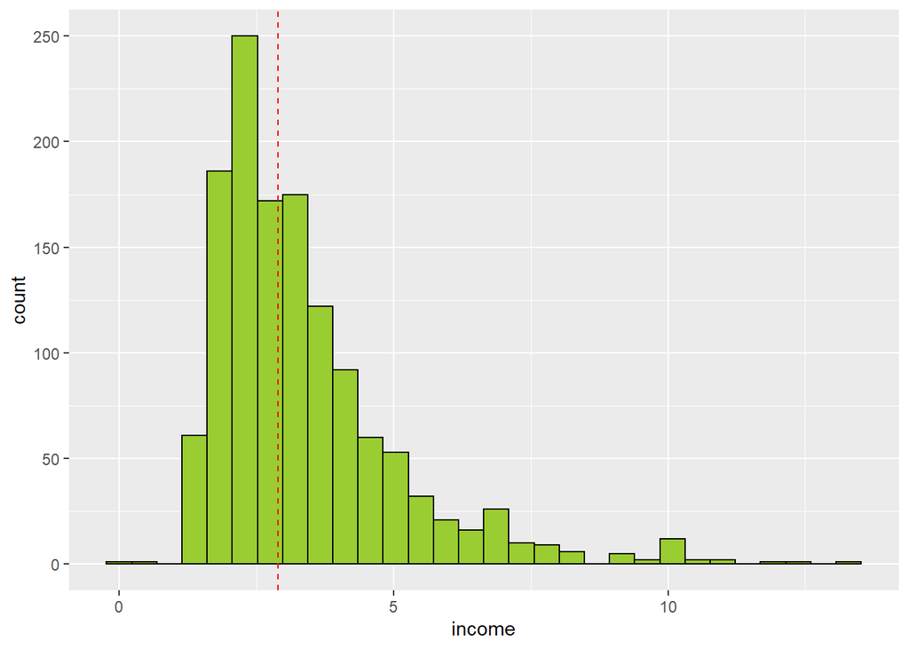

```r
library(ggplot2)

ggplot(data = df, aes(x = income)) +   #оценим распределение дохода
  geom_histogram(fill = "yellowgreen",
                 color = "black")+
  geom_vline(xintercept = median(df$income),
             color = "red",
             lty = 2)
```

Так как наблюдается сильная несиметричность, то рассмотрим новую переменую - log(income) и относительно нее сформируем собственый критерий:

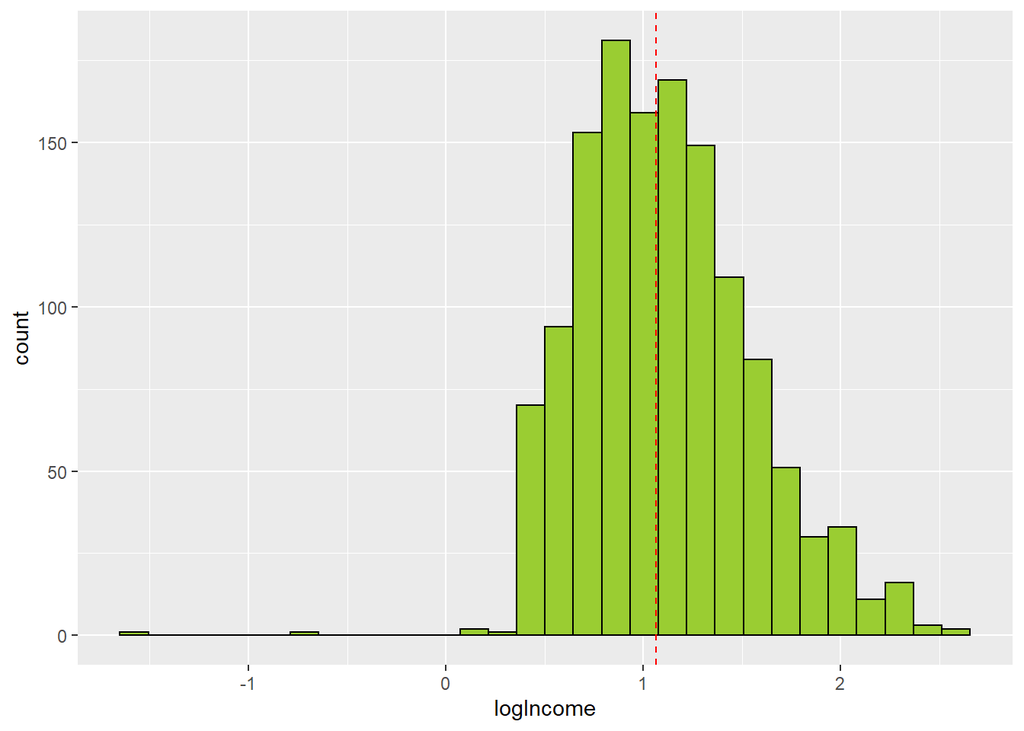

```r
df <- mutate(df, logIncome = log(income))

ggplot(data = df, aes(x = logIncome)) +   #оценим распределение log дохода
  geom_histogram(fill = "yellowgreen",
                 color = "black")+
  geom_vline(xintercept = median(df$logIncome),
             color = "red",
             lty = 2)
```

```r
scopes = quantile(df$logIncome, c(0.3255,0.6745))
```

Разделим по нашему критерию, где “3” - высокий достаток, “2” - средний, “1” - низкий.

```r
df <- df %>% mutate(myCrit = case_when(
                                  (logIncome >= scopes[[2]] ~ "3"),
                                  (logIncome >= scopes[[1]] & logIncome < scopes[[2]] ~ "2"),
                                  (logIncome < scopes[[1]]  ~ "1"),
                                  TRUE ~ "NA"))
df <- mutate(df, myCrit = as.factor(myCrit))
head(df)
```

```
##   card reports      age income       share expenditure owner selfemp dependents
## 1  yes       0 37.66667 4.5200 0.033269910  124.983300   yes      no          3
## 2  yes       0 33.25000 2.4200 0.005216942    9.854167    no      no          3
## 3  yes       0 33.66667 4.5000 0.004155556   15.000000   yes      no          4
## 4  yes       0 30.50000 2.5400 0.065213780  137.869200    no      no          0
## 5  yes       0 32.16667 9.7867 0.067050590  546.503300   yes      no          2
## 6  yes       0 23.25000 2.5000 0.044438400   91.996670    no      no          0
##   months majorcards active days inPerFamMem logIncome myCrit
## 1     54          1     12 1643    1.130000 1.5085120      3
## 2     34          1     13 1035    0.605000 0.8837675      1
## 3     58          1      5 1766    0.900000 1.5040774      3
## 4     25          1      7  762    2.540000 0.9321641      2
## 5     64          1      5 1947    3.262233 2.2810243      3
## 6     54          1      1 1643    2.500000 0.9162907      2
```

- Information about only self-employed people should be reported
- Use colon as a field separator

Выведем подсет данных в файл, где наш критерий >= 2, selfemp = yes, разделитель - “:”

```r
df_ <- df

subset <- filter(df_, as.numeric(myCrit) >= 2 &
                      selfemp == "yes"
                 )
write.table(subset, file = "myData.txt", sep = ":",
            row.names = TRUE, col.names = NA)
```

2. Print some information about dataset (either to file or to standard output)
- Average amount of dependents for people don’t own their home.

```r
owner_no <- filter(df, owner == "no")
summarise(owner_no, mean(dependents))
```

```
##   mean(dependents)
## 1        0.6517615
```

- Average age in each income groups (use grouping variable defined in 1.)

```r
by_age <- df %>% group_by(myCrit) %>% summarize_all("mean")
by_age$age
```

```
## [1] 29.72814 32.04886 37.43603
```

- Top 5 youngest and eldest people, whose application was declined

```r
subset <- filter(df, card == "no")
subset <- arrange(subset, age)
head(subset,5)
```

```
##   card reports      age income        share expenditure owner selfemp
## 1   no       0  0.75000   3.00 0.0004000000           0    no      no
## 2   no       0 19.00000   1.97 0.0006091371           0    no      no
## 3   no       0 19.41667   2.20 0.0005454546           0    no      no
## 4   no       0 19.50000   1.56 0.0007692308           0   yes      no
## 5   no       0 19.58333   2.10 0.0005714286           0    no      no
##   dependents months majorcards active days inPerFamMem logIncome myCrit
## 1          0     18          0      2  547       3.000 1.0986123      2
## 2          1     24          1      2  731       0.985 0.6780335      1
## 3          0      6          1      0  182       2.200 0.7884574      1
## 4          0     46          0      3 1400       1.560 0.4446858      1
## 5          0    124          1      2 3773       2.100 0.7419373      1
```

```r
tail(subset,5)
```

```
##     card reports      age income        share expenditure owner selfemp
## 292   no       6 62.91667 2.5500 0.0004705882           0    no      no
## 293   no       1 63.41667 2.1375 0.0005614035           0   yes      no
## 294   no       0 66.50000 3.2500 0.0003692308           0   yes      no
## 295   no       0 69.75000 1.8000 0.0006666667           0   yes      no
## 296   no       0 80.16666 1.5000 0.0008000000           0    no      no
##     dependents months majorcards active  days inPerFamMem logIncome myCrit
## 292          2     20          0     13   609      0.8500 0.9360934      2
## 293          0    240          1      7  7305      2.1375 0.7596369      1
## 294          3    300          1     13  9132      0.8125 1.1786550      2
## 295          0    528          0      5 16071      1.8000 0.5877867      1
## 296          0     24          1      0   731      1.5000 0.4054651      1
```

- Average number of major CCs held for people with top 10 income

```r
df_ <- head(arrange(df, desc(income)), 10)
mean(df_$majorcards)
```

```
## [1] 0.9
```

## Task 2

1. Опишите распределения данных по возрасту, полу и уровню дохода

К сожалению в данных нету информации про пол претендентов, поэтому опишем распределения данных только по возрасту и уровню дохода.

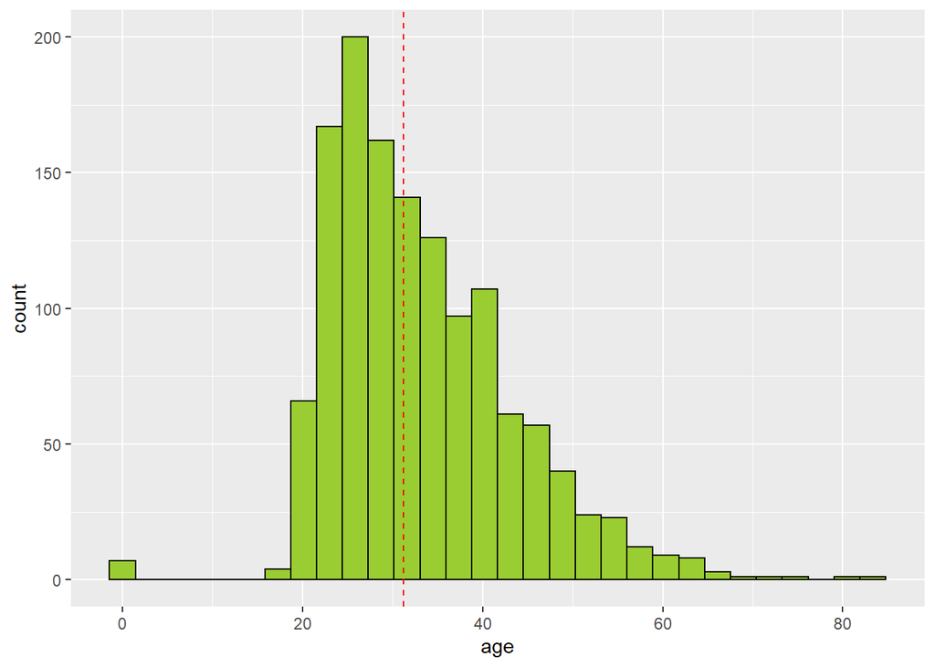

```r
ggplot(data = df, aes(x = age)) +
  geom_histogram(fill = "yellowgreen",
                 color = "black")+
  geom_vline(xintercept = median(df$age),
             color = "red",
             lty = 2)
```

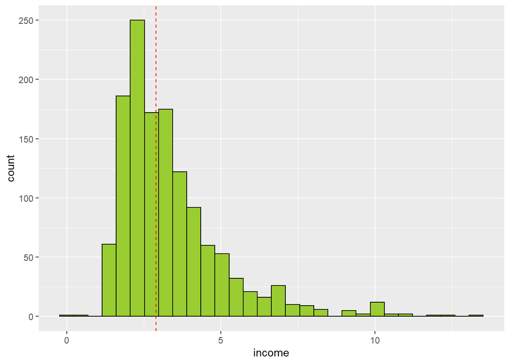

```r
ggplot(data = df, aes(x = income)) +
  geom_histogram(fill = "yellowgreen",
                 color = "black")+
  geom_vline(xintercept = median(df$income),
             color = "red",
             lty = 2)
```

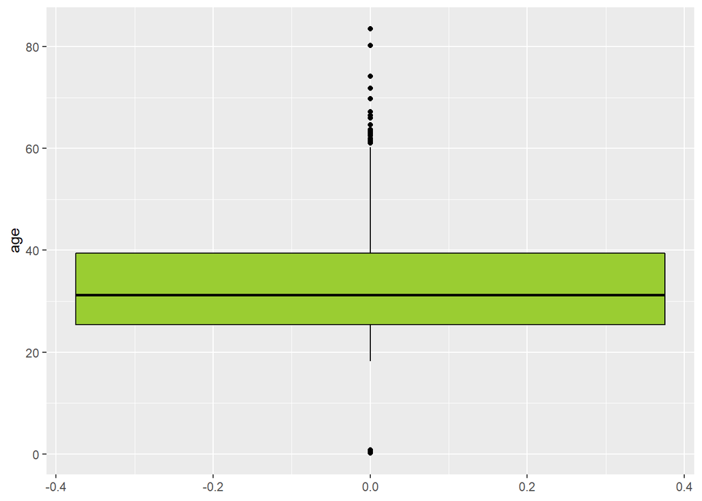

```r
ggplot(data = df, aes(y = age)) +
  geom_boxplot(fill = "yellowgreen",
                 color = "black")
```

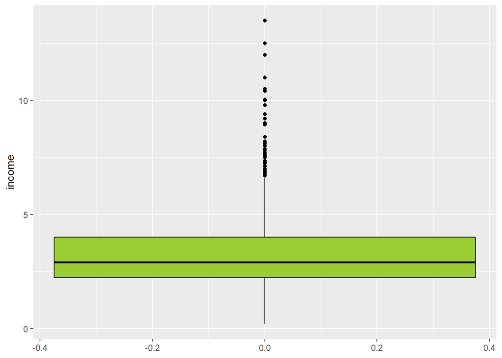

```r
ggplot(data = df, aes(y = income)) +
  geom_boxplot(fill = "yellowgreen",
                 color = "black")
```

2. Опишите структуру трат Так как распределения не симметричны, прологарифмируем данные income и expenditure:

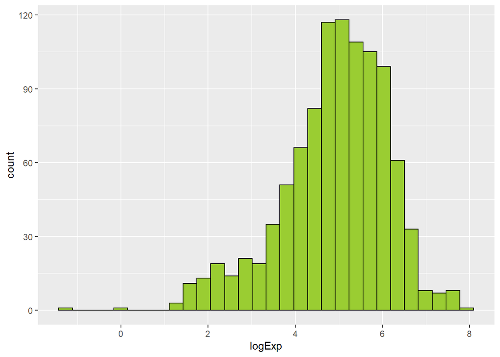

```r
df <- mutate(df, logIncome = log(income),
                 logExp = log(expenditure),
                 logShare = log(share))


ggplot(data = df, aes(x = logExp)) +
  geom_histogram(fill = "yellowgreen",
                 color = "black")
```

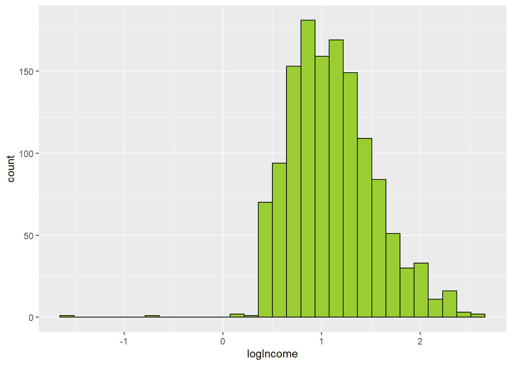

```r
ggplot(data = df, aes(x = logIncome)) +
  geom_histogram(fill = "yellowgreen",
                 color = "black")
```

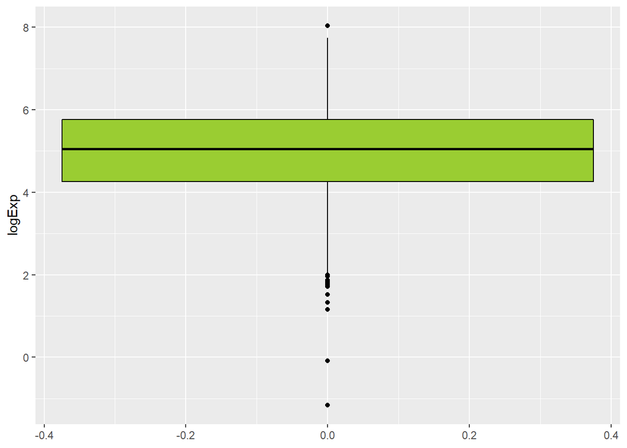

```r
ggplot(data = df, aes(y = logExp)) +
  geom_boxplot(fill = "yellowgreen",
                 color = "black")
```

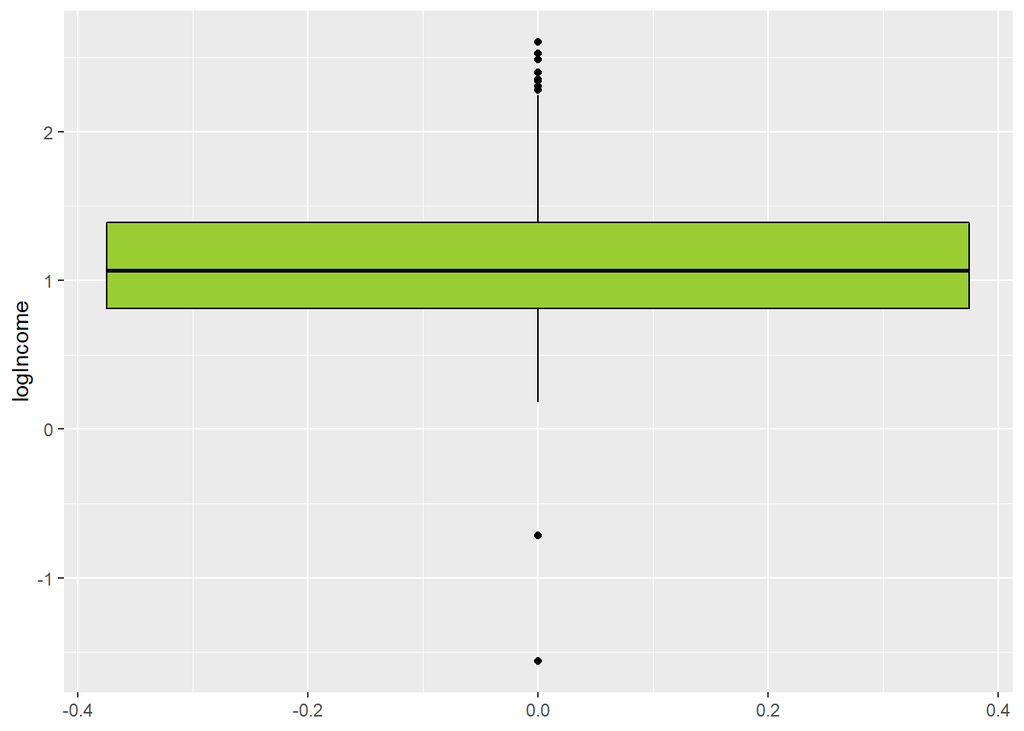

```r
ggplot(data = df, aes(y = logIncome)) +
  geom_boxplot(fill = "yellowgreen",
                 color = "black")
```

```r
library(psych)
```

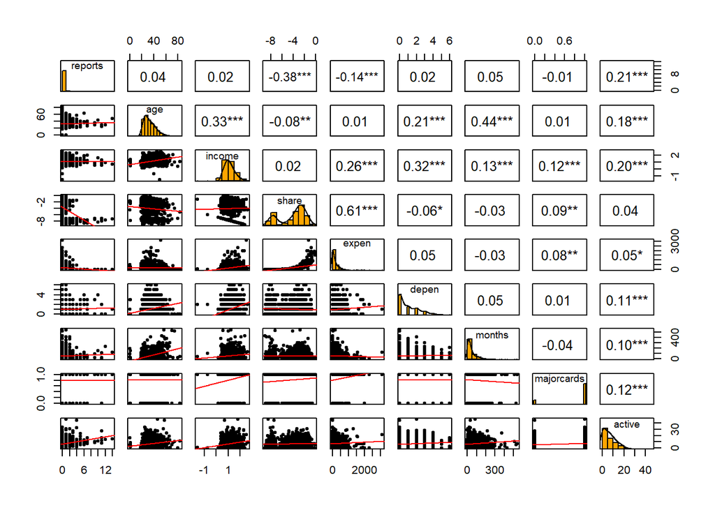

```r
df_for_cor <- data.frame( "reports"    = df$reports,
                          "age"        = df$age,
                          "income"     = df$logIncome,
                          "share"      = df$logShare,
                          "expen"      = df$expenditure,
                          "depen"      = df$dependents,
                          "months"     = df$months,
                          "majorcards" = df$majorcards,
                          "active"     = df$active)

pairs.panels(df_for_cor,
             method = "pearson",
             hist.col = "orange",
             density = TRUE,
             ellipses = FALSE,
             lm = TRUE,
             stars = TRUE
             )
```

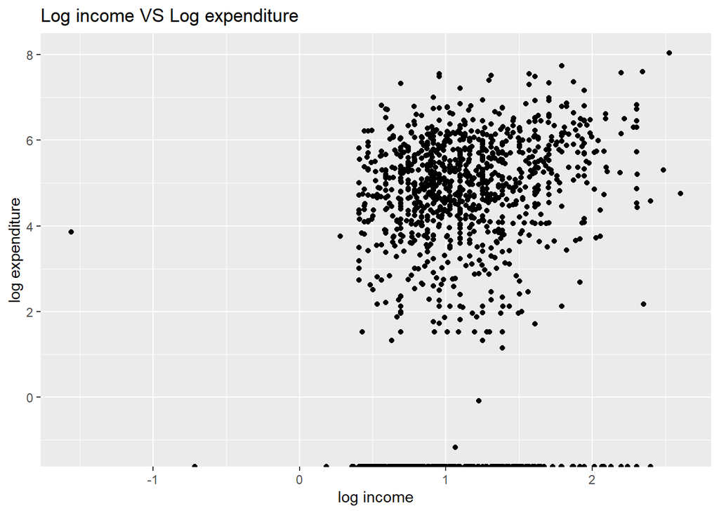

```r
ggplot(data = df, aes(x = logIncome, y = logExp)) +
geom_point() +
labs(title = "Log income VS Log expenditure",
     x = "log income",
     y = "log expenditure")
```

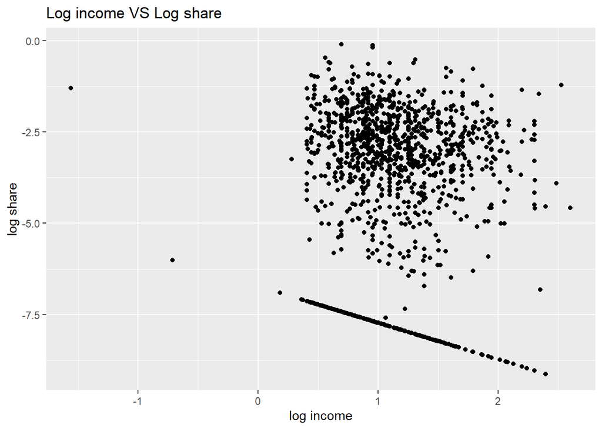

```r
ggplot(data = df, aes(x = logIncome, y = logShare)) +
geom_point() +
labs(title = "Log income VS Log share",
     x = "log income",
     y = "log share")
```

[figure not shown]

```r
ggplot(data = df, aes(x = age, y = logIncome)) +
geom_point() +
labs(title = "Log income VS Log share",
     x = "age",
     y = "log income")
```

3. Опишите зависимость, выдана карта, или нет от других признаков

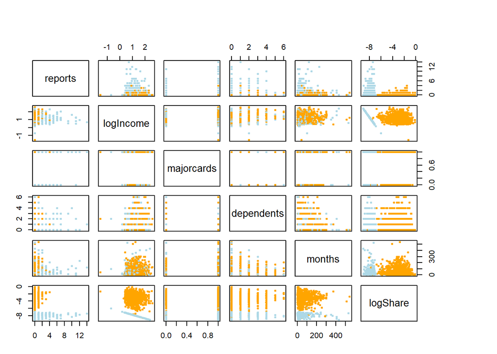

```r
df$card <- revalue(df$card, c("yes" = 2, "no" = 1))
df$card <- as.numeric(df$card)

my_cols <- c("light blue", "orange")
pairs(~ reports + logIncome + majorcards + dependents + months + logShare, data = df, col = my_cols[df$card], pch = 19,  cex = 0.5, oma=c(3,3,6,8))
```